# Clustering Lab

1. We will be looking at the `avocado` dataset used for the week 11 weekend homework.
2. Build a decision tree to model the likelihood of a sale being of an organic avocado.
3. Use k-means clustering to investigate potential relationships in the `USArrests` dataset we looked at in the hierarchical clustering lesson?
- Explore the data - do you think it looks potentially suitable for clustering?
- Chose a value of k
- Create clusters with chosen value of k - pull out the sizes of the clusters and the average of each variable in the dataset for each cluster.
- Visualise the clusters (Hint - there is more than 2 variables in the dataset so refer to the classnotes about how to visualise).

## Decision Tree

```r
library(janitor)
library(yardstick)
library(modelr)
library(fastDummies)
library(broom)
library(rpart)
library(rpart.plot)
library(tidyverse)
library(factoextra)
```

Load in the data

```r
avocados <- read_csv("data/avocado.csv")
```

Clean up names and remove variables to match our model:

```r
avocados_tidy <- avocados %>%
                clean_names() %>%
                select(-c("x1", "small_bags", "large_bags", "x_large_bags"))

glimpse(avocados_tidy)
```

```
## Rows: 18,249
## Columns: 10
## $ date          <date> 2015-12-27, 2015-12-20, 2015-12-13, 2015-12-06, 2015-1…
## $ average_price <dbl> 1.33, 1.35, 0.93, 1.08, 1.28, 1.26, 0.99, 0.98, 1.02, 1…
## $ total_volume  <dbl> 64236.62, 54876.98, 118220.22, 78992.15, 51039.60, 5597…
## $ x4046         <dbl> 1036.74, 674.28, 794.70, 1132.00, 941.48, 1184.27, 1368…
## $ x4225         <dbl> 54454.85, 44638.81, 109149.67, 71976.41, 43838.39, 4806…
## $ x4770         <dbl> 48.16, 58.33, 130.50, 72.58, 75.78, 43.61, 93.26, 80.00…
## $ total_bags    <dbl> 8696.87, 9505.56, 8145.35, 5811.16, 6183.95, 6683.91, 8…
## $ type          <chr> "conventional", "conventional", "conventional", "conven…
## $ year          <dbl> 2015, 2015, 2015, 2015, 2015, 2015, 2015, 2015, 2015, 2…
## $ region        <chr> "Albany", "Albany", "Albany", "Albany", "Albany", "Alba…
```

Create train/test datasets:

```r
n_data <- nrow(avocados_tidy)
test_index <- sample(1:n_data, size = n_data*0.2)

avo_test  <- slice(avocados_tidy, test_index)
avo_train <- slice(avocados_tidy, -test_index)
```

```r
avo_test %>%
 tabyl(type)
```

```
##          type    n   percent
##  conventional 1823 0.4995889
##       organic 1826 0.5004111
```

```r
avo_test %>%
 tabyl(type)
```

```
##          type    n   percent
##  conventional 1823 0.4995889
##       organic 1826 0.5004111
```

Build the tree

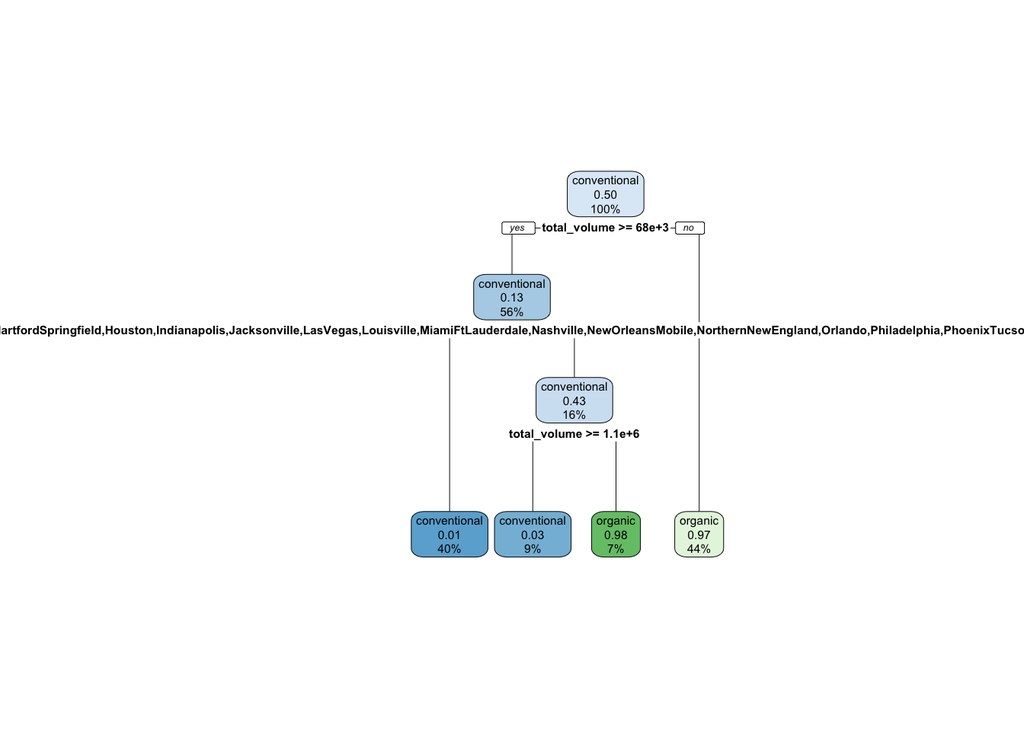

```r
avo_fit <- rpart(type ~ ., data = avo_train, method = 'class')
rpart.plot(avo_fit)
```

Use trained model to create predictions on test dataset

```r
avo_test_pred <- avo_test %>%
                 add_predictions(avo_fit, type = 'class')


head(avo_test_pred)
```

```
## # A tibble: 6 x 11
##   date       average_price total_volume  x4046  x4225 x4770 total_bags type
##   <date>             <dbl>        <dbl>  <dbl>  <dbl> <dbl>      <dbl> <chr>
## 1 2016-12-25          1.41       46896. 3.55e3 9.03e3  279.     34034. orga…
## 2 2018-01-07          1.18       85028. 2.72e4 2.19e4  488.     35463. conv…
## 3 2016-02-14          1.24       14196. 6.48e3 5.24e1    0       7666. orga…
## 4 2016-11-20          1.89      510752. 1.21e5 3.09e5 2239.     78967. conv…
## 5 2017-11-05          1.71        6330. 7.29e1 1.96e3    0       4300. orga…
## 6 2017-06-25          1.67      111509. 4.35e3 3.72e4  153.     69823. orga…
## # … with 3 more variables: year <dbl>, region <chr>, pred <fct>
```

Build confidence matrix and check accuracy:

```r
#type has come through as a charcter so need to change to a factor for the conf_mat() and accuracy()
#also need to reorder 'the factor 'type' so comes through in the same level orders as 'pred'
avo_test_pred <- avo_test_pred %>%
    mutate(type = as_factor(type)) %>%
    mutate(type = fct_relevel(type, "conventional", "organic"))

avo_test_pred %>%
              conf_mat(truth = type, estimate = pred)
```

```
##               Truth
## Prediction     conventional organic
##   conventional         1756      25
##   organic                67    1801
```

```r
avo_test_pred %>%
 accuracy(truth = type, estimate = pred)
```

```
## # A tibble: 1 x 3
##   .metric  .estimator .estimate
##   <chr>    <chr>          <dbl>
## 1 accuracy binary         0.975
```

## Clustering

Load data and perform same cleaning as in hierarchical clustering lesson:

```r
arrests <- USArrests %>%
              janitor::clean_names()

head(arrests)
```

```
##            murder assault urban_pop rape
## Alabama      13.2     236        58 21.2
## Alaska       10.0     263        48 44.5
## Arizona       8.1     294        80 31.0
## Arkansas      8.8     190        50 19.5
## California    9.0     276        91 40.6
## Colorado      7.9     204        78 38.7
```

Scale and check

```r
arrests_scale <- arrests %>%
                      mutate_all(scale)

summary(arrests_scale)
```

```
##       murder.V1            assault.V1          urban_pop.V1
##  Min.   :-1.6044046   Min.   :-1.5090416   Min.   :-2.3171363
##  1st Qu.:-0.8524835   1st Qu.:-0.7410815   1st Qu.:-0.7627068
##  Median :-0.1235217   Median :-0.1411127   Median : 0.0317794
##  Mean   : 0.0000000   Mean   : 0.0000000   Mean   : 0.0000000
##  3rd Qu.: 0.7948553   3rd Qu.: 0.9388312   3rd Qu.: 0.8435371
##  Max.   : 2.2068599   Max.   : 1.9947764   Max.   : 1.7589234
##        rape.V1
##  Min.   :-1.4874469
##  1st Qu.:-0.6573508
##  Median :-0.1208577
##  Mean   : 0.0000000
##  3rd Qu.: 0.5277383
##  Max.   : 2.6443501
```

Explore the data

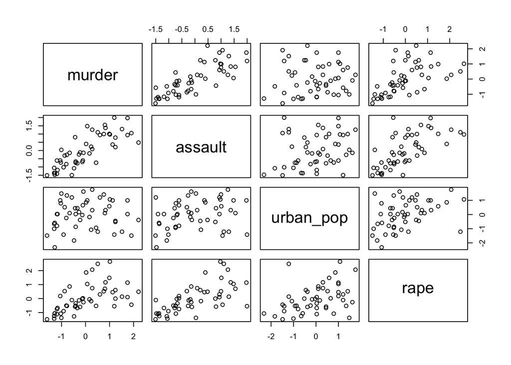

```r
plot(arrests_scale)
```

Although some condensed overlap there is also some dispersion in the data so potential for meaningful clusters so let’s cluster and see what we get

Check sum of squares within clusters

```r
# Set min & max number of clusters want to look at
max_k <- 20

k_clusters_arrests <- tibble(k = 2:max_k) %>%
  mutate(
    kclust = map(k, ~ kmeans(arrests_scale, .x, nstart = 25),),
   tidied = map(kclust, tidy),
    glanced = map(kclust, glance),
  augmented = map(kclust, augment, arrests_scale )
  )

k_clusters_arrests
```

```
## # A tibble: 19 x 5
##        k kclust   tidied            glanced          augmented
##    <int> <list>   <list>            <list>           <list>
##  1     2 <kmeans> <tibble [2 × 7]>  <tibble [1 × 4]> <tibble [50 × 5]>
##  2     3 <kmeans> <tibble [3 × 7]>  <tibble [1 × 4]> <tibble [50 × 5]>
##  3     4 <kmeans> <tibble [4 × 7]>  <tibble [1 × 4]> <tibble [50 × 5]>
##  4     5 <kmeans> <tibble [5 × 7]>  <tibble [1 × 4]> <tibble [50 × 5]>
##  5     6 <kmeans> <tibble [6 × 7]>  <tibble [1 × 4]> <tibble [50 × 5]>
##  6     7 <kmeans> <tibble [7 × 7]>  <tibble [1 × 4]> <tibble [50 × 5]>
##  7     8 <kmeans> <tibble [8 × 7]>  <tibble [1 × 4]> <tibble [50 × 5]>
##  8     9 <kmeans> <tibble [9 × 7]>  <tibble [1 × 4]> <tibble [50 × 5]>
##  9    10 <kmeans> <tibble [10 × 7]> <tibble [1 × 4]> <tibble [50 × 5]>
## 10    11 <kmeans> <tibble [11 × 7]> <tibble [1 × 4]> <tibble [50 × 5]>
## 11    12 <kmeans> <tibble [12 × 7]> <tibble [1 × 4]> <tibble [50 × 5]>
## 12    13 <kmeans> <tibble [13 × 7]> <tibble [1 × 4]> <tibble [50 × 5]>
## 13    14 <kmeans> <tibble [14 × 7]> <tibble [1 × 4]> <tibble [50 × 5]>
## 14    15 <kmeans> <tibble [15 × 7]> <tibble [1 × 4]> <tibble [50 × 5]>
## 15    16 <kmeans> <tibble [16 × 7]> <tibble [1 × 4]> <tibble [50 × 5]>
## 16    17 <kmeans> <tibble [17 × 7]> <tibble [1 × 4]> <tibble [50 × 5]>
## 17    18 <kmeans> <tibble [18 × 7]> <tibble [1 × 4]> <tibble [50 × 5]>
## 18    19 <kmeans> <tibble [19 × 7]> <tibble [1 × 4]> <tibble [50 × 5]>
## 19    20 <kmeans> <tibble [20 × 7]> <tibble [1 × 4]> <tibble [50 × 5]>
```

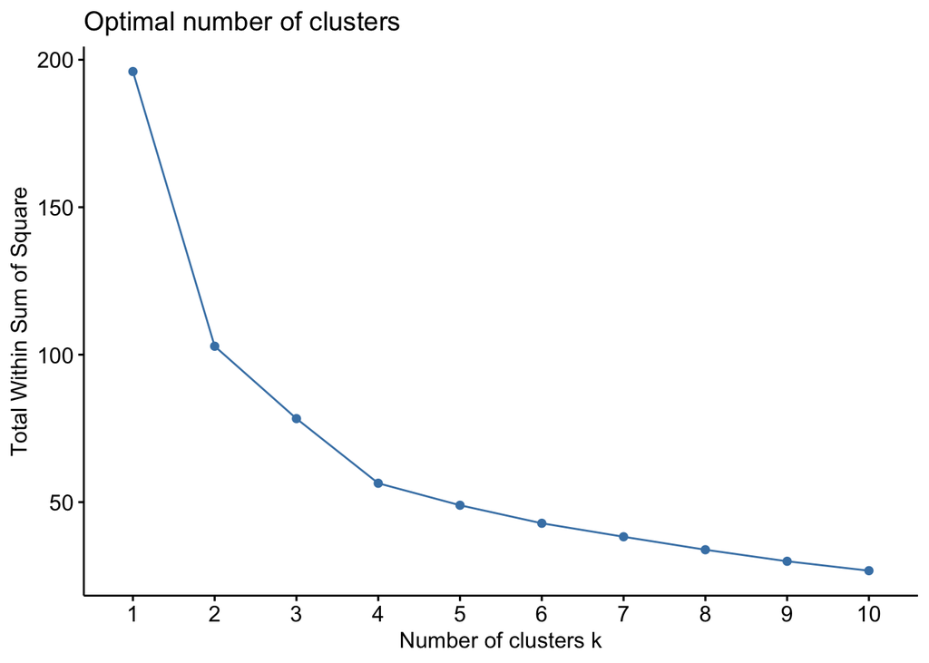

```r
fviz_nbclust(arrests_scale, kmeans, method = "wss", nstart = 25)
```

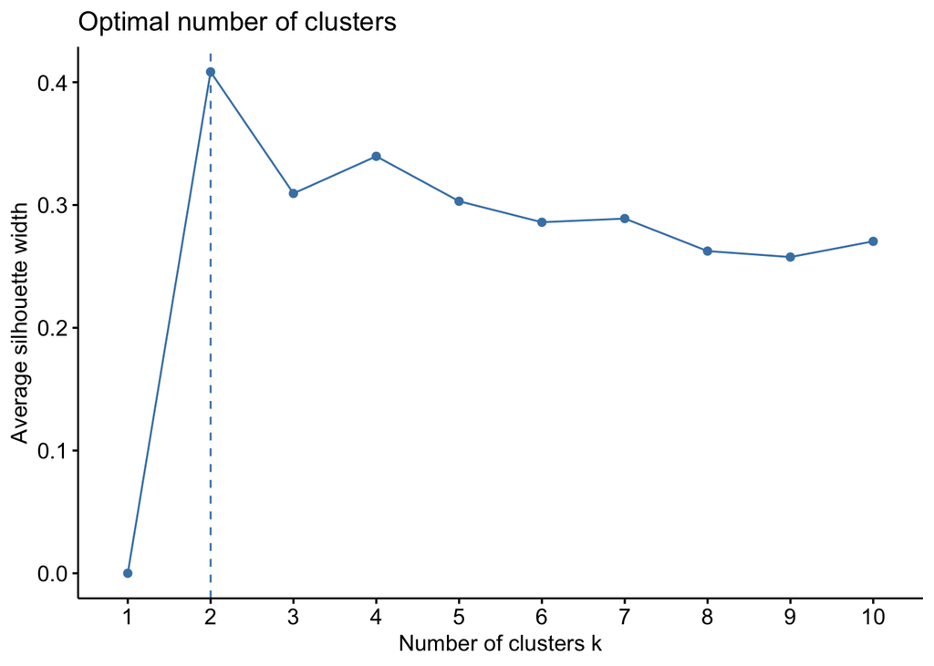

```r
fviz_nbclust(arrests_scale, kmeans, method = "silhouette", nstart = 25)
```

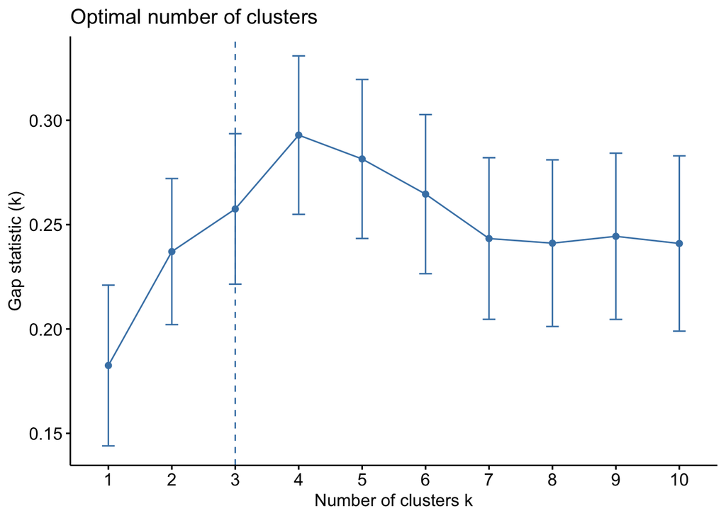

```r
fviz_nbclust(arrests_scale, kmeans, method = "gap_stat", nstart = 25)
```

Elbow gives a result of 4 and 4 is close to the maximum for both the other methods.

```r
k4_clusters_arrests <- kmeans(arrests_scale, 4, nstart = 25)

k4_clusters_arrests
```

```
## K-means clustering with 4 clusters of sizes 13, 13, 8, 16
##
## Cluster means:
##       murder    assault  urban_pop        rape
## 1 -0.9615407 -1.1066010 -0.9301069 -0.96676331
## 2  0.6950701  1.0394414  0.7226370  1.27693964
## 3  1.4118898  0.8743346 -0.8145211  0.01927104
## 4 -0.4894375 -0.3826001  0.5758298 -0.26165379
##
## Clustering vector:
##  [1] 3 2 2 3 2 2 4 4 2 3 4 1 2 4 1 4 1 3 1 2 4 2 1 3 2 1 1 2 1 4 2 2 3 1 4 4 4 4
## [39] 4 3 1 3 2 4 1 4 4 1 1 4
##
## Within cluster sum of squares by cluster:
## [1] 11.952463 19.922437  8.316061 16.212213
##  (between_SS / total_SS =  71.2 %)
##
## Available components:
##
## [1] "cluster"      "centers"      "totss"        "withinss"     "tot.withinss"
## [6] "betweenss"    "size"         "iter"         "ifault"
```

Pull out the cluster means and sizes for your chosen number of clusters.

```r
k4_clusters_arrests$size
```

```
## [1] 13 13  8 16
```

```r
k4_clusters_arrests$centers
```

```
##       murder    assault  urban_pop        rape
## 1 -0.9615407 -1.1066010 -0.9301069 -0.96676331
## 2  0.6950701  1.0394414  0.7226370  1.27693964
## 3  1.4118898  0.8743346 -0.8145211  0.01927104
## 4 -0.4894375 -0.3826001  0.5758298 -0.26165379
```

Visualise the clusters.

As mentioned in the classnotes going to use `fviz_cluster()` to perform PCA and visualise the data.

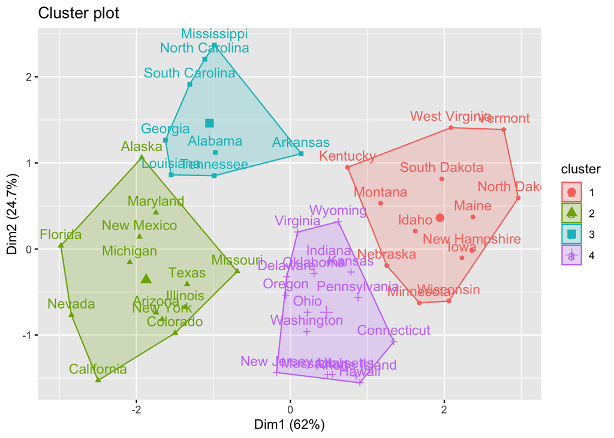

```r
#add rownames back on
rownames(arrests_scale) <- rownames(arrests)

fviz_cluster(k4_clusters_arrests, arrests_scale)
```